# Deep Learning & Artificial Intelligence

A human centered perspective

Fanli (Christian) Zheng https://www.linkedin.com/in/christianramsey/ (dyad x machina)https://dyadxmachina.com , Haohan Wang https://www.linkedin.com/in/haohanw/ (dyad x machina)https://dyadxmachina.com  
Nov 24, 2018

*Draft*

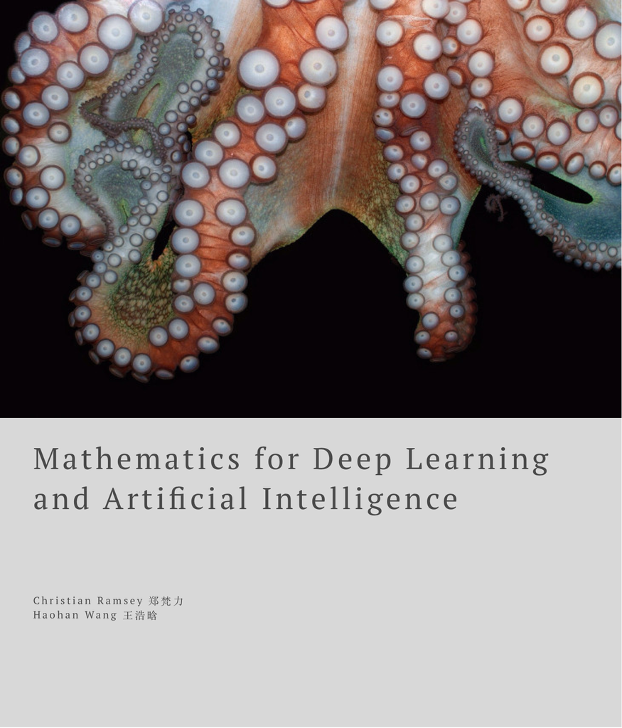

# Introduction to Artificial Intelligence

## Just what is artificial intelligence?

Artificial intelligence is harder to describe infinite terms than it is to recreate many of the most popular algorithms that serve to represent it.

> The definition, if we can say that such a thing exists, is a moving socio-cultural target and just as we get closer to it’s said definition, it again slips just outside of our grasp.

This is partly because AI has always been fundamentally tied up with some of our deepest philosophical queries and as we make further progress in AI and related sciences, we again are forced to redraw the line of what it means to be human.

> “Nothing that we may know or learn about the functioning of the organism can give, without ‘microscopic,’ cytological work any clues regarding the further details of the neural mechanism.” - Von Neumann

Generation after generation, we’ve asked ourselves fundamental questions that AI, as a philosophical project, touches upon:

Neurobiologists like Sapolsky and others, have highlighted that many of the features we have held so dearly, empathy, politics, culture, tool usage, are not unique to the human species. It seems that is the only true advantage may be in the sheer number of neurons (86 billion) and synaptic connections (100 trillion+) between them that has allowed for more elaborate and subtle ways of those elements unfolding over time.

“We have the same nuts-and-bolts physiology, yet we’re using it in very novel ways. - Robert Sapolsky”

While scientific discoveries continue to redraw the line of what is truly unique to humans, so does progress in artificial intelligence. So while it is clear that there is much hype around artificial intelligence, it can not be argued that there shouldn’t be at least some concern over its possible futures.

Rather than focus on the takeover, we will focus here on intelligence and some of the major categorisations that have played a part in today’s AI.

## Intelligence as logic and reasoning

- can correct reasoning be mechanized?

> Perhaps there is a logic calculus than can mechanise reasoning

These are just some of the questions that the likes of Aristotle, Leibniz, Turing, Laplace, Wittgenstein, Gödel, and Boole and others attempted to answer definitively. Aristotle and the Stoics gave us a framework for reasoning and propositional logic respectively. Leibniz gave us logical calculi and a glimpse into computers that could do the same. We also have George Boole’s Boolean algebra (1847) would catch up with Claude Shannon to begin the digital revolution and progress artificial intelligence.

Let us think about the context of such questions.

## Reasoning and Logic

Rene Descartes stated “Cogito, ergo sum” which translated means, “I think therefore I am”. He arrived at this statement after trying to use pure “reason” to find what was fundamentally true without any doubt. Although he couldn’t complete his project, his value of “reason” was not unpopular and is gaining popularity in much of modern culture and can be heard in everyday conversations when we talk about the distinction between our thoughts and body.

Reasoning starts with logic.

So let us begin with reasoning.

The branch and discipline titled logic was originally focused on finding absolute truths from statements that could be found in everyday discourse. Logic is fundamentally tied up with questions around how one can reason correctly. How one is able to deduce the correct answer given a set of statements or propositions.

## Dealing with Uncertainty and Probability

While Boole was transforming the world of logic, the likes of Kolmogorov, Laplace, Jaynes and others were setting out to find a way for us to better reason when we didn’t have complete information and especially when we had data from several different places.

Jaynes even described probability as an extension of logic. But there were others who didn’t see them as connected at all.

### Information Theory

While logic and probability were now firmly established, Claude Shannon combined probability, logic, to create the mathematical theory of communication which we now call **Information Theory**.

While probability allows us to reason under uncertainty, Shannon’s information theory allowed us to quantify the uncertainty with a measure called $entropy$. This has lead to many concepts including mutual information, KL divergence, and even a very popular deep learning loss function. (Encoder-decoder or data compression strategies)

## The Rise of AI and Neuroscience

## Neurobiology and Cognitive Science

### Perceptrons and Perception

Pitts, McCulloch, Rosenblatt, Minsky, and others set out to combine the advances of logic, from Leibniz’s logical calculi to Bool’s Boolean algebra) and combine it with our growing knowledge in brain science which eventually leads to the creation of the first artificial neural network, named the perceptron. The first neural network which was based in the science of logic pushed forward by the likes of Leibniz and George Boole.

## The Limits of Logic

Though we don’t usually think of logic in neural networks, the perceptron was actually based on logic as you can see from the references to Pitts paper are all around logic.

## Statistical Learning Theory

Vapnik, the learnable theorems PAC learning bounds

## The modern wave of deep neural networks

Bengio, LeCunn Andrew Ng Hinton, Goodfellow

## Deepmind, OpenAI, and so on

## Why learn the mathematics of deep learning

## The Mathematics Needed

- Logic
- Calculus
- Probability
- Geometry (?)
- Information Theory – entropy – mutual information – bottleneck
- Statistical Learning Theory – approximation theory – learnable
- Representation Learning
- Optimization

### Final Thoughts

Whatever your motivations for wanting to read the Mathematics of Deep Learning and Artificial Intelligence, we wish you well on your journey.

++++

You may also need to cover a little bit more about the following questions:

++++